# FIFA2019

Ricardo Alberich

18 de marzo de 2019

En [FIFA 19 complete player dataset 18k+ FIFA 19 players, ~90 attributes extracted from the latest FIFA database](https://www.kaggle.com/karangadiya/fifa19#data.csv)

Tenemos acceso al data set de los jugadores del videojuego FIFA 2019. La información que aporta la página es la siguiente (para más información acudid a la página):

*About this file*

*data.csv includes lastest edition FIFA 2019 players attributes like Age, Nationality, Overall, Potential, Club, Value, Wage, Preferred Foot, International Reputation, Weak Foot, Skill Moves, Work Rate, Position, Jersey Number, Joined, Loaned From, Contract Valid Until, Height, Weight, LS, ST, RS, LW, LF, CF, RF, RW, LAM, CAM, RAM, LM, LCM, CM, RCM, RM, LWB, LDM, CDM, RDM, RWB, LB, LCB, CB, RCB, RB, Crossing, Finishing, Heading, Accuracy, ShortPassing, Volleys, Dribbling, Curve, FKAccuracy, LongPassing, BallControl, Acceleration, SprintSpeed, Agility, Reactions, Balance, ShotPower, Jumping, Stamina, Strength, LongShots, Aggression, Interceptions, Positioning, Vision, Penalties, Composure, Marking, StandingTackle, SlidingTackle, GKDiving, GKHandling, GKKicking, GKPositioning, GKReflexes, and Release Clause.*

## 0.1 Carga de los datos

Cragamos los datos y los visualizamos

```r
data=read.csv("data.csv",stringsAsFactors = FALSE)
#data$Nationality=as.factor(data$Nationality)
head(data)
```

```
## # A tibble: 6 x 89
##     ï..     ID Name    Age Photo Nationality Flag  Overall Potential Club
##   <int>  <int> <chr> <int> <chr> <chr>       <chr>   <int>     <int> <chr>
## 1     0 158023 L. M~    31 http~ Argentina   http~      94        94 FC B~
## 2     1  20801 Cris~    33 http~ Portugal    http~      94        94 Juve~
## 3     2 190871 Neym~    26 http~ Brazil      http~      92        93 Pari~
## 4     3 193080 De G~    27 http~ Spain       http~      91        93 Manc~
## 5     4 192985 K. D~    27 http~ Belgium     http~      91        92 Manc~
## 6     5 183277 E. H~    27 http~ Belgium     http~      91        91 Chel~
## # ... with 79 more variables: Club.Logo <chr>, Value <chr>, Wage <chr>,
## #   Special <int>, Preferred.Foot <chr>, International.Reputation <int>,
## #   Weak.Foot <int>, Skill.Moves <int>, Work.Rate <chr>, Body.Type <chr>,
## #   Real.Face <chr>, Position <chr>, Jersey.Number <int>, Joined <chr>,
## #   Loaned.From <chr>, Contract.Valid.Until <chr>, Height <chr>, Weight <chr>,
## #   LS <chr>, ST <chr>, RS <chr>, LW <chr>, LF <chr>, CF <chr>, RF <chr>,
## #   RW <chr>, LAM <chr>, CAM <chr>, RAM <chr>, LM <chr>, LCM <chr>, CM <chr>,
## #   RCM <chr>, RM <chr>, LWB <chr>, LDM <chr>, CDM <chr>, RDM <chr>, RWB <chr>,
## #   LB <chr>, LCB <chr>, CB <chr>, RCB <chr>, RB <chr>, Crossing <int>,
## #   Finishing <int>, HeadingAccuracy <int>, ShortPassing <int>, Volleys <int>,
## #   Dribbling <int>, Curve <int>, FKAccuracy <int>, LongPassing <int>,
## #   BallControl <int>, Acceleration <int>, SprintSpeed <int>, Agility <int>,
## #   Reactions <int>, Balance <int>, ShotPower <int>, Jumping <int>,
## #   Stamina <int>, Strength <int>, LongShots <int>, Aggression <int>,
## #   Interceptions <int>, Positioning <int>, Vision <int>, Penalties <int>,
## #   Composure <int>, Marking <int>, StandingTackle <int>, SlidingTackle <int>,
## #   GKDiving <int>, GKHandling <int>, GKKicking <int>, GKPositioning <int>,
## #   GKReflexes <int>, Release.Clause <chr>
```

```r
str(data)
```

```
## 'data.frame':    18207 obs. of  89 variables:
##  $ ï..                     : int  0 1 2 3 4 5 6 7 8 9 ...
##  $ ID                      : int  158023 20801 190871 193080 192985 183277 177003 176580 155862 200389 ...
##  $ Name                    : chr  "L. Messi" "Cristiano Ronaldo" "Neymar Jr" "De Gea" ...
##  $ Age                     : int  31 33 26 27 27 27 32 31 32 25 ...
##  $ Photo                   : chr  "https://cdn.sofifa.org/players/4/19/158023.png" "https://cdn.sofifa.org/players/4/19/20801.png" "https://cdn.sofifa.org/players/4/19/190871.png" "https://cdn.sofifa.org/players/4/19/193080.png" ...
##  $ Nationality             : chr  "Argentina" "Portugal" "Brazil" "Spain" ...
##  $ Flag                    : chr  "https://cdn.sofifa.org/flags/52.png" "https://cdn.sofifa.org/flags/38.png" "https://cdn.sofifa.org/flags/54.png" "https://cdn.sofifa.org/flags/45.png" ...
##  $ Overall                 : int  94 94 92 91 91 91 91 91 91 90 ...
##  $ Potential               : int  94 94 93 93 92 91 91 91 91 93 ...
##  $ Club                    : chr  "FC Barcelona" "Juventus" "Paris Saint-Germain" "Manchester United" ...
##  $ Club.Logo               : chr  "https://cdn.sofifa.org/teams/2/light/241.png" "https://cdn.sofifa.org/teams/2/light/45.png" "https://cdn.sofifa.org/teams/2/light/73.png" "https://cdn.sofifa.org/teams/2/light/11.png" ...
##  $ Value                   : chr  "â‚¬110.5M" "â‚¬77M" "â‚¬118.5M" "â‚¬72M" ...
##  $ Wage                    : chr  "â‚¬565K" "â‚¬405K" "â‚¬290K" "â‚¬260K" ...
##  $ Special                 : int  2202 2228 2143 1471 2281 2142 2280 2346 2201 1331 ...
```

[output cut: 75 more lines]

## 0.2 Algunos estadisticos por nacionalidad

Calculamos la media de la edad de los jugadores por nacionalidad. Como hay muchas nacionalidades ordenamos y visualizamos las o nacionalidades más abundantes.

```r
head(aggregate(Age~Nationality,data=data,FUN=mean))
```

```
## # A tibble: 6 x 2
##   Nationality         Age
##   <chr>             <dbl>
## 1 Afghanistan        22.5
## 2 Albania            24.0
## 3 Algeria            27.0
## 4 Andorra            28
## 5 Angola             25.9
## 6 Antigua & Barbuda  22.8
```

```r
head(sort(table(data$Nationality),decreasing = TRUE))
```

```
##
##   England   Germany     Spain Argentina    France    Brazil
##      1662      1198      1072       937       914       827
```

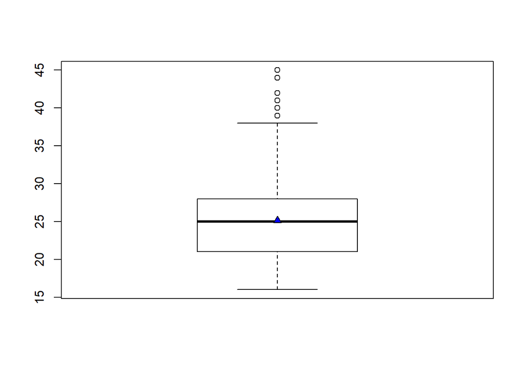

```r
boxplot(data$Age)
points(mean(data$Age),pch=24,bg="blue")
```

Dibujamos todos las frecuencias de la nacionalidades. Seleccionando las 10 más frecuentes

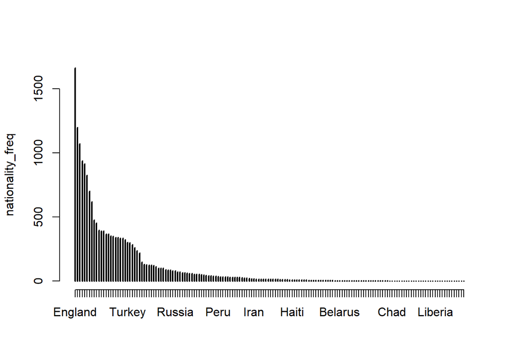

```r
nationality_freq=sort(table(data$Nationality),decreasing=TRUE)
plot(nationality_freq)# no se ve seleccionemos  top 10
```

```r
selected_nationalities=names(nationality_freq)[1:10]
selected_nationalities
```

```
##  [1] "England"     "Germany"     "Spain"       "Argentina"   "France"
##  [6] "Brazil"      "Italy"       "Colombia"    "Japan"       "Netherlands"
```

```r
selected_data=data[data$Nationality %in% selected_nationalities,]
```

Para las 10 nacionalidades más frecuentes dibujamos el diagrama de cajas de las edades

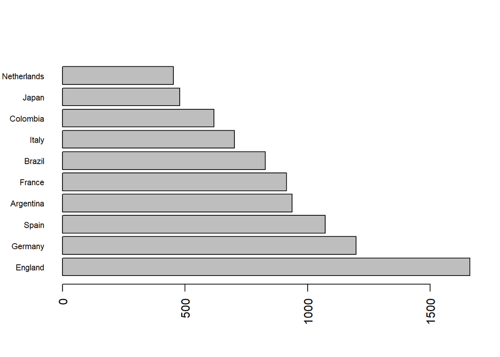

```r
nationality_freq=sort(table(selected_data$Nationality),decreasing=TRUE)
barplot(nationality_freq,las=2,cex.names=0.7,horiz=TRUE)# alerat cex.names
```

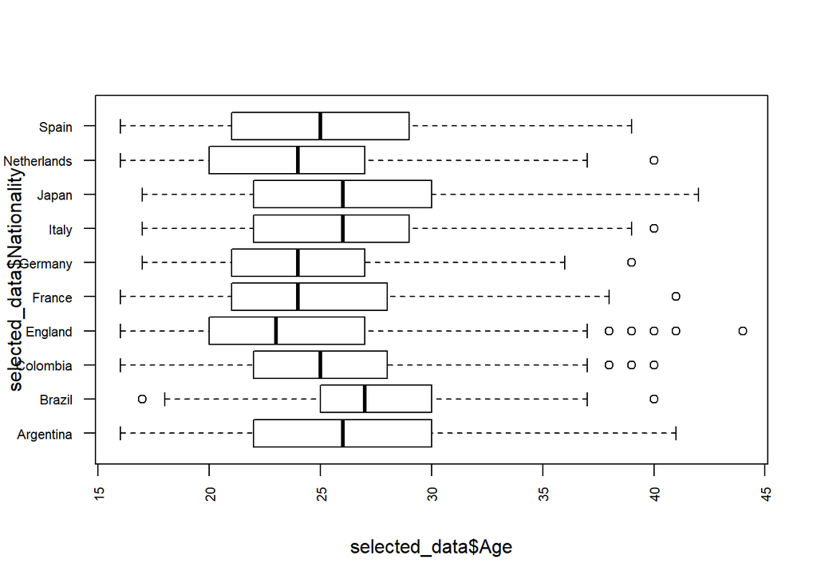

```r
boxplot(selected_data$Age~selected_data$Nationality,horizontal=TRUE,las=2,cex.axis=0.7)# alerta cex.names
```

# 1 Preguntas

## 1.1 Pregunta 1

¿Que proporción de jugadores su Overall es igual a su Potencial?

## 1.2 Pregunta 2

Crea una data frame llamado `data4` a partir de `data` con solo los jugadores de los equipos “FC Barcelona”, “Juventus”,“Paris Saint-Germain” “Manchester United”.

```r
data4=data[data$Club %in% c("FC Barcelona", "Juventus","Paris Saint-Germain", "Manchester United"),]
head(data4)
```

```
## # A tibble: 6 x 89
##     ï..     ID Name    Age Photo Nationality Flag  Overall Potential Club
##   <int>  <int> <chr> <int> <chr> <chr>       <chr>   <int>     <int> <chr>
## 1     0 158023 L. M~    31 http~ Argentina   http~      94        94 FC B~
## 2     1  20801 Cris~    33 http~ Portugal    http~      94        94 Juve~
## 3     2 190871 Neym~    26 http~ Brazil      http~      92        93 Pari~
## 4     3 193080 De G~    27 http~ Spain       http~      91        93 Manc~
## 5     7 176580 L. S~    31 http~ Uruguay     http~      91        91 FC B~
## 6    15 211110 P. D~    24 http~ Argentina   http~      89        94 Juve~
## # ... with 79 more variables: Club.Logo <chr>, Value <chr>, Wage <chr>,
## #   Special <int>, Preferred.Foot <chr>, International.Reputation <int>,
## #   Weak.Foot <int>, Skill.Moves <int>, Work.Rate <chr>, Body.Type <chr>,
## #   Real.Face <chr>, Position <chr>, Jersey.Number <int>, Joined <chr>,
## #   Loaned.From <chr>, Contract.Valid.Until <chr>, Height <chr>, Weight <chr>,
## #   LS <chr>, ST <chr>, RS <chr>, LW <chr>, LF <chr>, CF <chr>, RF <chr>,
## #   RW <chr>, LAM <chr>, CAM <chr>, RAM <chr>, LM <chr>, LCM <chr>, CM <chr>,
## #   RCM <chr>, RM <chr>, LWB <chr>, LDM <chr>, CDM <chr>, RDM <chr>, RWB <chr>,
## #   LB <chr>, LCB <chr>, CB <chr>, RCB <chr>, RB <chr>, Crossing <int>,
## #   Finishing <int>, HeadingAccuracy <int>, ShortPassing <int>, Volleys <int>,
## #   Dribbling <int>, Curve <int>, FKAccuracy <int>, LongPassing <int>,
## #   BallControl <int>, Acceleration <int>, SprintSpeed <int>, Agility <int>,
## #   Reactions <int>, Balance <int>, ShotPower <int>, Jumping <int>,
## #   Stamina <int>, Strength <int>, LongShots <int>, Aggression <int>,
## #   Interceptions <int>, Positioning <int>, Vision <int>, Penalties <int>,
## #   Composure <int>, Marking <int>, StandingTackle <int>, SlidingTackle <int>,
## #   GKDiving <int>, GKHandling <int>, GKKicking <int>, GKPositioning <int>,
## #   GKReflexes <int>, Release.Clause <chr>
```

## 1.3 Pregunta 3

Discretiza a un factor ordenado llamado `Overall_Level` en 5 niveles (“Low”,“Regular”,“Best”,“Very Best”,“Ace”), el Overall de los jugadores de `data4`.

```r
Overall_Level=ordered(cut(data4$Overall,breaks=5),labels=c("Low","Regular","Best","Very Best","Ace"))
Overall_Level
```

```
##   [1] Ace       Ace       Ace       Ace       Ace       Ace       Ace
##   [8] Ace       Ace       Ace       Ace       Ace       Ace       Ace
##  [15] Very Best Very Best Very Best Very Best Very Best Very Best Very Best
##  [22] Very Best Very Best Very Best Very Best Very Best Very Best Very Best
##  [29] Very Best Very Best Very Best Very Best Very Best Very Best Very Best
##  [36] Very Best Very Best Very Best Very Best Very Best Very Best Very Best
##  [43] Very Best Very Best Very Best Very Best Very Best Very Best Very Best
##  [50] Very Best Very Best Very Best Very Best Very Best Very Best Very Best
##  [57] Very Best Very Best Very Best Very Best Very Best Very Best Very Best
##  [64] Very Best Best      Best      Best      Best      Best      Best
##  [71] Best      Best      Best      Best      Best      Best      Best
##  [78] Best      Best      Best      Best      Best      Best      Best
##  [85] Best      Best      Best      Regular   Regular   Regular   Regular
##  [92] Regular   Regular   Regular   Regular   Regular   Regular   Regular
##  [99] Regular   Low       Low       Low       Low       Low       Low
## [106] Low       Low       Low       Low       Low       Low       Low
## [113] Low       Low       Low       Low       Low       Low       Low
## [120] Low       Low
## Levels: Low < Regular < Best < Very Best < Ace
```

# 2 Pregunta 4

Dibuja un diagrama de mosaico de las proporciones globales de Overall_Level por los 4 clubes.

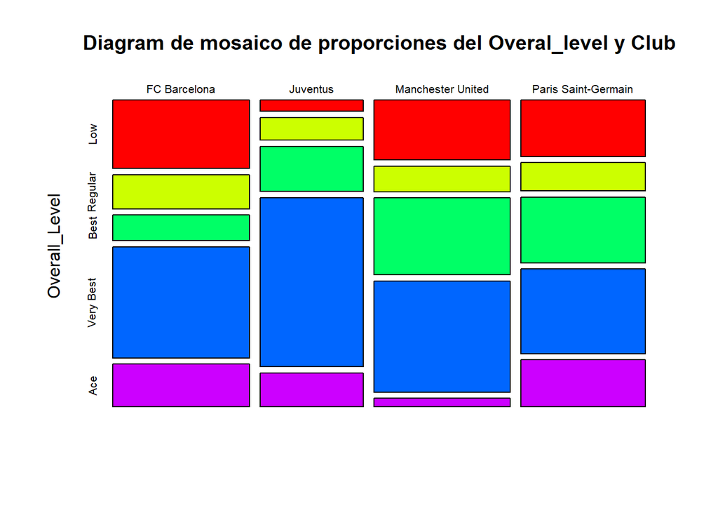

```r
mosaicplot(prop.table(table(data4$Club,Overall_Level)),main="Diagram de mosaico de proporciones del Overal_level y Club",color = rainbow(5))
```

# 3 Pregunta 5

Calcula los porcentajes de `Overall_Level` por club. ¿Qué club tiene un mayor porcentaje de jugadores Ace?.

```r
prop.table(table(Overall_Level,data4$Club),margin=2)
```

```
##
## Overall_Level FC Barcelona   Juventus Manchester United Paris Saint-Germain
##     Low         0.24242424 0.04000000        0.21212121          0.20000000
##     Regular     0.12121212 0.08000000        0.09090909          0.10000000
##     Best        0.09090909 0.16000000        0.27272727          0.23333333
##     Very Best   0.39393939 0.60000000        0.39393939          0.30000000
##     Ace         0.15151515 0.12000000        0.03030303          0.16666667
```

# 4 Pregunta 6

Del total de Ace entre los 4 clubes ¿qué club tiene el menor porcentaje?

```r
prop.table(table(Overall_Level,data4$Club),margin=1)
```

```
##
## Overall_Level FC Barcelona   Juventus Manchester United Paris Saint-Germain
##     Low         0.36363636 0.04545455        0.31818182          0.27272727
##     Regular     0.33333333 0.16666667        0.25000000          0.25000000
##     Best        0.13043478 0.17391304        0.39130435          0.30434783
##     Very Best   0.26000000 0.30000000        0.26000000          0.18000000
##     Ace         0.35714286 0.21428571        0.07142857          0.35714286
```

## 4.1 Pregunta 7

Calcula un diagrama de tarta de la proporción de Aces entre los 4 clubes

[figure not shown]

```r
pie(prop.table(table(Overall_Level,data4$Club),margin=2)[4,],main="Propociones de Ace entre los 4 clubes")
```

## 4.2 Pregunta 8

- 1. Calcula overall medio y la desviación tipica para cada uno de los 4 clubs
- 2. Dibuja en un mismo gráfico. los diagrama de caja de Overall para cada uno de los 4 clubs. Añade a cada diagram de caja el valor medio de Overall en forma de rombo del color de cada club.

```r
aggregate(Overall~Club,data=data4,FUN= function(x) {c(media=mean(x),sd=sd(x))})
```

```
## # A tibble: 4 x 2
##   Club                Overall[,"media"] [,"sd"]
##   <chr>                           <dbl>   <dbl>
## 1 FC Barcelona                     78.0    9.58
## 2 Juventus                         82.3    6.56
## 3 Manchester United                77.2    7.70
## 4 Paris Saint-Germain              77.4    9.02
```

```r
medias=medias=aggregate(Overall~Club,FUN=mean,data = data4)
medias
```

```
## # A tibble: 4 x 2
##   Club                Overall
##   <chr>                 <dbl>
## 1 FC Barcelona           78.0
## 2 Juventus               82.3
## 3 Manchester United      77.2
## 4 Paris Saint-Germain    77.4
```

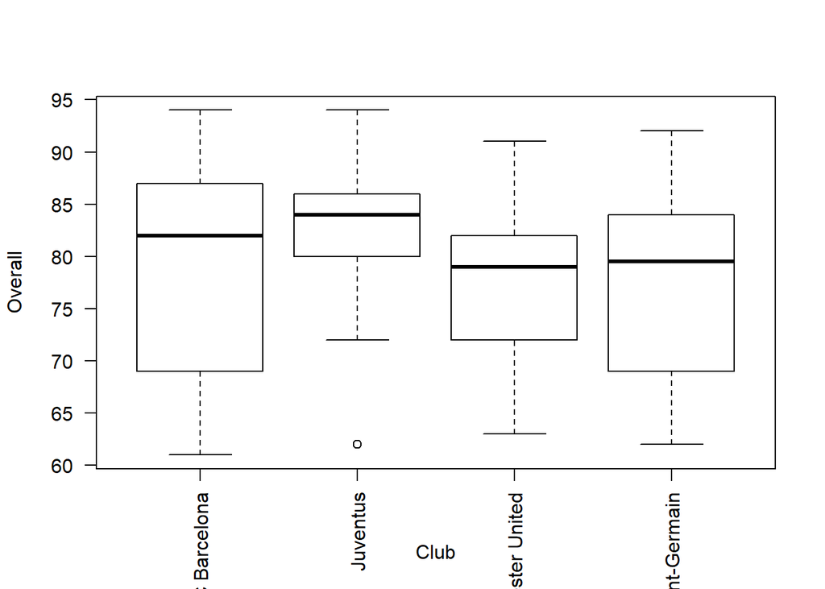

```r
boxplot(Overall~Club,data=data4,las=2)
points(medias,pch=24,col=rainbow(4),bg=rainbow(4))
```

## Pregunta 9 Hay un club con un dato atípico. Averiguar quién es, es decir da su nombre.

```r
x=which.min(data4$Overall[data4$Club=="Juventus"])
x
```

```
## [1] 25
```

```r
data4[x,"Name"]
```

```
## [1] "M. PjaniÄ‡"
```

## 4.3 Pregunta 10

Se puntua la presentación.